# Downloading data from NCEI, cropping, and coarsening

Resources:

- [Catalog of some datasets](https://data.noaa.gov/waf/NOAA/NESDIS/NGDC/MGG/DEM/iso/)
- [NCEI 1/9" tiles](https://data.noaa.gov//metaview/page?xml=NOAA/NESDIS/NGDC/MGG/DEM/iso/xml/999919.xml&view=getDataView&header=none)

```python
%matplotlib inline
```

```python
from pylab import *
```

```python
from clawpack.geoclaw import topotools
```

## Download topo from NCEI thredds server

### For etopo1 data use:

```python
etopo1_server = 'https://www.ngdc.noaa.gov/thredds/dodsC/global/ETOPO1_Ice_g_gmt4.nc'
```

We can crop and coarsen in the process, so that a much smaller file is downloaded.

Here we crop to a local region and coarsen by a factor 2 to create an array with 2 arc-minute resolution.

```python
extent = [-125,-122,47,49]
coarsen = 2
etopo1_subset = topotools.read_netcdf(etopo1_server, extent=extent,
                                      coarsen=coarsen, verbose=True)
```

```
Will read netCDF data from
    https://www.ngdc.noaa.gov/thredds/dodsC/global/ETOPO1_Ice_g_gmt4.nc
Returning a DEM with shape = (61, 91)
x ranges from -125.00000 to -122.00000 with dx = 0.03333333
y ranges from 47.00000 to 49.00000 with dy = 0.03333333
```

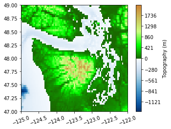

```python
etopo1_subset.plot()
```

## For coastal inundation DEMs use:

```python
server = 'https://www.ngdc.noaa.gov/thredds/dodsC/regional/'
```

Append to this the name of the netCDF file to access, e.g.

- 'astoria_13_mhw_2012.nc'
- 'puget_sound_13_mhw_2014.nc'
- 'port_townsend_13_mhw_2011.nc'
- 'strait_of_juan_de_fuca_13_navd88_2015.nc'

Again we can crop and coarsen in the process, so that a much smaller file is downloaded.

Here we crop to a smaller extent and coarsen by a factor 6 to create an array with 2 arc-second resolution.

```python
path = server + 'puget_sound_13_mhw_2014.nc'
extent = [-123, -122.3, 47.85, 48.04]
PS_subset_2sec = topotools.read_netcdf(path, extent=extent, coarsen=6, verbose=True)
```

```
Will read netCDF data from
    https://www.ngdc.noaa.gov/thredds/dodsC/regional/puget_sound_13_mhw_2014.nc
Returning a DEM with shape = (342, 1260)
x ranges from -122.99991 to -122.30046 with dx = 0.00055556
y ranges from 47.85009 to 48.03954 with dy = 0.00055556
```

### Check that this agrees with version from local file:

```python
if 1:
    path = '/Users/rjl/topo/WA/puget_sound_13_mhw_2014.nc'
    extent = [-123, -122.3, 47.85, 48.04]
    PS_subset_2sec_local = topotools.read_netcdf(path, extent=extent, coarsen=6, verbose=True)
    print('Difference in two Z arrays: ',\
          abs(PS_subset_2sec_local.Z - PS_subset_2sec.Z).max())
```

```
Will read netCDF data from
    /Users/rjl/topo/WA/puget_sound_13_mhw_2014.nc
Returning a DEM with shape = (342, 1260)
x ranges from -122.99991 to -122.30046 with dx = 0.00055556
y ranges from 47.85009 to 48.03954 with dy = 0.00055556
Difference in two Z arrays:  0.0
```

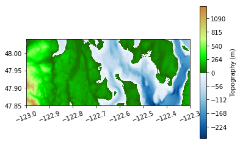

```python
PS_subset_2sec.plot()
```

## Plotting the topography

The topography object (e.g. `PS_subset_2sec` above) has a function `plot()` defined that makes a basic plot with a predetermined colormap as done above, often useful as a first pass.

You can make more fancy and customized plots with any Python plotting commands. The `X, Y, Z` attributes of the topography object (e.g. `PS_subset_2sec`) are numpy arrays of the respective variables.

## Grid registration

It is important to understand how the DEM is registered. When reading a netCDF file from the NCEI thredds server, the latitude and longitude arrays returned give the points where the DEM elevations `Z` are located. With earlier `.asc` files the the header often specified the lower left corner of a "grid cell" and the DEM values were located at cell centers. This has caused many headaches.

See http://www.clawpack.org/grid_registration.html for more discussion, and also:

- http://www.clawpack.org/topo.html
- [ESRI page](http://resources.esri.com/help/9.3/arcgisengine/java/GP_ToolRef/spatial_analyst_tools/esri_ascii_raster_format.htm)
- [NOAA page](https://www.ngdc.noaa.gov/mgg/global/gridregistration.html)

```python
print('X = \n',PS_subset_2sec.X[:2,:2])
print('Y = \n',PS_subset_2sec.Y[:2,:2])
print('Z = \n',PS_subset_2sec.Z[:2,:2])
```

```
X =
 [[-122.99990741 -122.99935186]
 [-122.99990741 -122.99935186]]
Y =
 [[47.85009259 47.85009259]
 [47.85064814 47.85064814]]
Z =
 [[898.593  899.0405]
 [859.3618 858.5129]]
```

## Saving a DEM for use in GeoClaw

```python
fname = 'PS_subset_2sec_sample.tt3'
PS_subset_2sec.write(fname, topo_type=3)
```

This file contains a header in the fist 6 lines, followed by one line for each row of the topo array.

Here is the header for the file just created:

```python
with open('PS_subset_2sec_sample.tt3','r') as my_file:
    for i in range(6):
        line = my_file.readline()
        print(line.strip())
```

```
1260                              ncols
342                              nrows
-1.229999074124550e+02              xlower
4.785009258558999e+01              ylower
5.555555399890000e-04              cellsize
-9999                          nodata_value
```

#### Read it back in and check the coordinates:

```python
topo = topotools.Topography()
topo.read(fname, topo_type=3)
print('X = \n',topo.X[:2,:2])
print('Y = \n',topo.Y[:2,:2])
print('Z = \n',topo.Z[:2,:2])
```

```
X =
 [[-122.99990741 -122.99935186]
 [-122.99990741 -122.99935186]]
Y =
 [[47.85009259 47.85009259]
 [47.85064814 47.85064814]]
Z =
 [[898.59302 899.04053]
 [859.36182 858.51288]]
```

## Write in asc format with `llcorner` registration:

Alternatively we could write it as:

```python
fname = 'PS_subset_2sec_sample.tt3'
PS_subset_2sec.write(fname, topo_type=3, header_style='asc',
                     grid_registration='llcorner')
```

`header_style='asc'` causes the labels to appear before the values (either way works when reading into GeoClaw).

`grid_registration='llcorner'` causes it to be written with a different header, and with the lower left corner shifted by 1/2 grid cell (at the current resolution).

#### Print the header:

```python
with open('PS_subset_2sec_sample.tt3','r') as my_file:
    for i in range(6):
        line = my_file.readline()
        print(line.strip())
```

```
ncols    1260
nrows     342
xllcorner  -1.230001851902250e+02
yllcorner   4.784981480781999e+01
cellsize  5.555555399890000e-04
nodata_value       -9999
```

#### Read it back in and check the coordinates:

```python
topo = topotools.Topography()
topo.read(fname, topo_type=3)
print('X = \n',topo.X[:2,:2])
print('Y = \n',topo.Y[:2,:2])
print('Z = \n',topo.Z[:2,:2])
```

```
*** Note: since grid registration is llcorner,
    will shift x,y values by (dx/2, dy/2) to cell centers
X =
 [[-122.99990741 -122.99935186]
 [-122.99990741 -122.99935186]]
Y =
 [[47.85009259 47.85009259]
 [47.85064814 47.85064814]]
Z =
 [[898.59302 899.04053]
 [859.36182 858.51288]]
```

Note that once read back in, the GeoClaw tool adjusts `X` and `Y` to again be the proper points.

## Alignment of data

The etopo1 data from thredds has data that lies exactly on integer values of longitude and latitude, with spacing of 1 arcminute in between. For example:

```python
print('X = \n',etopo1_subset.X[:2,:2])
print('Y = \n',etopo1_subset.Y[:2,:2])
print('Z = \n',etopo1_subset.Z[:2,:2])
```

```
X =
 [[-125.         -124.96666667]
 [-125.         -124.96666667]]
Y =
 [[47.         47.        ]
 [47.03333333 47.03333333]]
Z =
 [[-435. -160.]
 [-777. -297.]]
```

The coastal DEMs have the same alignment. For example, the first $X$ value in the `PS_subset_2sec` topography is 1/3" away from longitude $-123$. We didn't pick up that point itself because of the choice of cropping region and coarsening factor. Be careful what you ask for!

```python
x00 = PS_subset_2sec.X[0,0]
offset = (x00 + 123) * 3*3600.
print('X[0,0] is %.8f and lies %.6f times 1/3 arcsecond away from -123' % (x00, offset))
```

```
X[0,0] is -122.99990741 and lies 0.999945 times 1/3 arcsecond away from -123
```